# Анализ данных: Заработная плата и факторы влияния

Peter Tsivinsky / t.me/tsivi_sky

2024-12-20

# 1. Введение

В этом проекте мы анализируем данные о заработной плате и связанных с ней факторах, чтобы выявить закономерности и сделать выводы, которые могут быть полезны для понимания влияния различных характеристик, таких как опыт работы, уровень образования, должность, а также результаты экзаменов по математике и программированию на уровень дохода.

Основной задачей является продемонстрировать подходы к обработке и анализу данных с использованием языка программирования R, включая визуализацию результатов и выводы.

# 2. Загрузка библиотек и данных

## 2.1 Подключение библиотек

Для начала подключим необходимые библиотеки. Мы будем использовать `tidyverse` для обработки данных и визуализации, а также `skimr` для описательной статистики.

```r
# Установите пакеты, если они не установлены
# install.packages(c("tidyverse", "skimr", "readr"))

library(tidyverse)
library(skimr)
```

## 2.2 Загрузка данных

Данные находятся в файле `Salary_Data.csv`. Мы используем функцию `read_csv` для их загрузки. Для установки рабочей директории можно было бы воспользоваться `setwd`, но в таком варианте мы бы привязывались к структуре директорий на своём текущем рабочем месте и придётся редактировать проект, чтобы посмотреть его на другом компьютере. Поэтому лучше загрузить датасет на облачное хранилище и импортировать данные прямо оттуда.

```r
# Путь к файлу данных
file_path <- "https://raw.githubusercontent.com/wowxoxo/r-lang_project/refs/heads/master/data/Salary_Data.csv"

# Загрузка данных
salary_data <- read_csv(file_path)
# Проверим, что данные успешно загружены
head(salary_data)
```

```
## # A tibble: 6 × 8
##     Age Gender `Education Level` `Job Title`       `Years of Experience` Salary
##   <dbl> <chr>  <chr>             <chr>                             <dbl>  <dbl>
## 1    32 Male   Bachelor's        Software Engineer                     5  90000
## 2    28 Female Master's          Data Analyst                          3  65000
## 3    45 Male   PhD               Senior Manager                       15 150000
## 4    36 Female Bachelor's        Sales Associate                       7  60000
## 5    52 Male   Master's          Director                             20 200000
## 6    29 Male   Bachelor's        Marketing Analyst                     2  55000
## # ℹ 2 more variables: `Math exam score` <dbl>, `Programming exam score` <dbl>
```

### Наблюдения:

1. Данные успешно загружены. Таблица содержит такие переменные, как `Age`, `Salary`, `Years of Experience`, `Math exam score`, `Programming exam score`, `Gender`, `Education Level`, и `Job Title`.
2. Первые строки показывают, что данные выглядят корректными и готовы для анализа.

# 3. Первичная проверка данных

На этом этапе мы изучим структуру данных, проверим количество строк и столбцов, а также выявим потенциальные проблемы, такие как пропуски или некорректные типы даных.

```r
# Структура данных
str(salary_data)
```

```
## spc_tbl_ [6,698 × 8] (S3: spec_tbl_df/tbl_df/tbl/data.frame)
##  $ Age                   : num [1:6698] 32 28 45 36 52 29 42 31 26 38 ...
##  $ Gender                : chr [1:6698] "Male" "Female" "Male" "Female" ...
##  $ Education Level       : chr [1:6698] "Bachelor's" "Master's" "PhD" "Bachelor's" ...
##  $ Job Title             : chr [1:6698] "Software Engineer" "Data Analyst" "Senior Manager" "Sales Associate" ...
##  $ Years of Experience   : num [1:6698] 5 3 15 7 20 2 12 4 1 10 ...
##  $ Salary                : num [1:6698] 90000 65000 150000 60000 200000 55000 120000 80000 45000 110000 ...
##  $ Math exam score       : num [1:6698] 49 71 77 69 42 63 86 56 67 39 ...
##  $ Programming exam score: num [1:6698] 45 73 76 84 41 69 88 52 74 45 ...
##  - attr(*, "spec")=
##   .. cols(
##   ..   Age = col_double(),
##   ..   Gender = col_character(),
##   ..   `Education Level` = col_character(),
##   ..   `Job Title` = col_character(),
##   ..   `Years of Experience` = col_double(),
##   ..   Salary = col_double(),
##   ..   `Math exam score` = col_double(),
##   ..   `Programming exam score` = col_double()
##   .. )
##  - attr(*, "problems")=<externalptr>
```

```r
# Количество строк и столбцов
cat("Количество строк:", nrow(salary_data), "\n")
```

```
## Количество строк: 6698
```

```r
cat("Количество столбцов:", ncol(salary_data), "\n")
```

```
## Количество столбцов: 8
```

```r
# Описательная статистика
skim(salary_data)
```

Data summary

| Name | salary_data |
| --- | --- |
| Number of rows | 6698 |
| Number of columns | 8 |
| _______________________ |  |
| Column type frequency: |  |
| character | 3 |
| numeric | 5 |
| ________________________ |  |
| Group variables | None |

**Variable type: character**

| skim_variable | n_missing | complete_rate | min | max | empty | n_unique | whitespace |
| --- | --- | --- | --- | --- | --- | --- | --- |
| Gender | 0 | 1 | 4 | 6 | 0 | 3 | 0 |
| Education Level | 0 | 1 | 3 | 17 | 0 | 7 | 0 |
| Job Title | 0 | 1 | 3 | 37 | 0 | 191 | 0 |

**Variable type: numeric**

| skim_variable | n_missing | complete_rate | mean | sd | p0 | p25 | p50 | p75 | p100 | hist |
| --- | --- | --- | --- | --- | --- | --- | --- | --- | --- | --- |
| Age | 0 | 1 | 33.62 | 7.62 | 21 | 28 | 32 | 38 | 62 | ▇▇▃▂▁ |
| Years of Experience | 0 | 1 | 8.10 | 6.06 | 0 | 3 | 7 | 12 | 34 | ▇▆▂▁▁ |
| Salary | 0 | 1 | 115329.25 | 52789.79 | 350 | 70000 | 115000 | 160000 | 250000 | ▃▇▇▇▁ |
| Math exam score | 0 | 1 | 65.84 | 13.72 | 3 | 57 | 66 | 76 | 100 | ▁▁▅▇▂ |
| Programming exam score | 0 | 1 | 66.96 | 13.64 | 12 | 58 | 68 | 76 | 100 | ▁▁▆▇▂ |

### Наблюдения:

1. **Типы данных:** Столбцы содержат числовые переменные, такие как `Age`, `Salary`, и `Years of Experience`, а также категориальные переменные, включая `Gender`, `Education Level`, и `Job Title`. Типы данных определены корректно.
2. **Размер данных:** Набор данных включает 6698 строк и 8 столбцов, что соответствует требованиям.
3. **Пропуски:** Пропуски отсутствуют, что подтверждает высокое качество набора данных.
4. **Распределения:** С помощью `skim()` видно, что данные распределены достаточно широко, особенно для таких переменных, как зарплата и опыт работы, что обещает интересные инсайты при дальнейшем анализе.

# 4. Предобработка данных

## 4.1 Приведение названий колонок к нижнему регистру

Названия столбцов приводим к единому формату для удобства работы.

```r
# Приведение названий к нижнему регистру
names(salary_data) <- tolower(names(salary_data))

# Проверяем изменения
names(salary_data)
```

```
## [1] "age"                    "gender"                 "education level"
## [4] "job title"              "years of experience"    "salary"
## [7] "math exam score"        "programming exam score"
```

## 4.2 Преобразование названий столбцов

```r
# Установим и подключим janitor, если он ещё не установлен
# install.packages("janitor")
library(janitor)
# Преобразование всех имен столбцов к удобному формату
salary_data <- salary_data %>% clean_names()

# Проверим результат
colnames(salary_data)
```

```
## [1] "age"                    "gender"                 "education_level"
## [4] "job_title"              "years_of_experience"    "salary"
## [7] "math_exam_score"        "programming_exam_score"
```

Комментарии: - Все названия столбцов преобразованы в нижний регистр с заменой пробелов на подчёркивания (_). - Например, `years of experience` теперь стало `years_of_experience`, а `math exam score` — `math_exam_score`.

## 4.3 Обработка пропусков

Если в данных есть пропуски, мы их обрабатываем. Например, можно удалить строки с пропусками или заполнить их средним значением.

```r
# Проверка пропусков
colSums(is.na(salary_data))
```

```
##                    age                 gender        education_level
##                      0                      0                      0
##              job_title    years_of_experience                 salary
##                      0                      0                      0
##        math_exam_score programming_exam_score
##                      0                      0
```

```r
# В данном случае пропусков нет, но если бы они были, можно применить следующий код:
# salary_data <- salary_data %>% drop_na()
```

### Комментарии:

Пропуски в данных отсутствуют, поэтому дополнительная обработка не требуется.

# 5. Фильтрация данных

Например, мы можем оставить только записи, где `salary` выше определённого порога.

```r
# Пример фильтрации данных
example_filtered_data <- salary_data %>% filter(salary > 50000)

# Проверим результат фильтрации
nrow(example_filtered_data)
```

```
## [1] 5827
```

```r
# это просто пример, будем работать с полным датасетом, без фильтрации
```

# 6. Описательная статистика

## 6.1 Описательные статистики для числовых переменных

```r
# Описательные статистики для числовых переменных
summary(select(salary_data, age, years_of_experience, salary, math_exam_score, programming_exam_score))
```

```
##       age        years_of_experience     salary       math_exam_score
##  Min.   :21.00   Min.   : 0.000      Min.   :   350   Min.   :  3.00
##  1st Qu.:28.00   1st Qu.: 3.000      1st Qu.: 70000   1st Qu.: 57.00
##  Median :32.00   Median : 7.000      Median :115000   Median : 66.00
##  Mean   :33.62   Mean   : 8.095      Mean   :115329   Mean   : 65.84
##  3rd Qu.:38.00   3rd Qu.:12.000      3rd Qu.:160000   3rd Qu.: 76.00
##  Max.   :62.00   Max.   :34.000      Max.   :250000   Max.   :100.00
##  programming_exam_score
##  Min.   : 12.00
##  1st Qu.: 58.00
##  Median : 68.00
##  Mean   : 66.96
##  3rd Qu.: 76.00
##  Max.   :100.00
```

## 6.2 Частоты для категориальных переменных

```r
cat("Gender:\n")
```

```
## Gender:
```

```r
print(table(salary_data$gender))
```

```
##
## Female   Male  Other
##   3013   3671     14
```

```r
cat("\nEducation Level:\n")
```

```
##
## Education Level:
```

```r
print(table(salary_data$education_level))
```

```
##
##        Bachelor's Bachelor's Degree       High School          Master's
##               756              2265               448               288
##   Master's Degree               phD               PhD
##              1572                 1              1368
```

```r
cat("\nJob Title:\n")
```

```
##
## Job Title:
```

```r
print(salary_data %>%
  count(job_title))
```

```
## # A tibble: 191 × 2
##    job_title                         n
##    <chr>                         <int>
##  1 Account Manager                   1
##  2 Accountant                        1
##  3 Administrative Assistant          2
##  4 Back end Developer              244
##  5 Business Analyst                  2
##  6 Business Development Manager      1
##  7 Business Intelligence Analyst     1
##  8 CEO                               1
##  9 Chief Data Officer                1
## 10 Chief Technology Officer          1
## # ℹ 181 more rows
```

```r
cat("\nJob Title (Top 10):\n")
```

```
##
## Job Title (Top 10):
```

```r
print(head(sort(table(salary_data$job_title), decreasing = TRUE), 10))
```

```
##
##         Software Engineer            Data Scientist Software Engineer Manager
##                       518                       453                       376
##              Data Analyst   Senior Project Engineer           Product Manager
##                       363                       318                       313
##       Full Stack Engineer         Marketing Manager        Back end Developer
##                       308                       255                       244
##  Senior Software Engineer
##                       244
```

## 6.3 Анализ поля gender

В данных присутствует 3 уникальных значения в поле gender. Это может указывать на некорректные данные или опечатки. Давайте изучим их подробнее.

### Проверка уникальных значений

Используем функцию `unique()` для вывода всех уникальных значений поля gender.

```r
unique(salary_data$gender)
```

```
## [1] "Male"   "Female" "Other"
```

Видим значение Other, скорее всего кто-то не указал пол при проведении исследований. Проверим насколько их много, чтобы оценить влияние на датасет

```r
# Частоты значений в поле gender
table(salary_data$gender)
```

```
##
## Female   Male  Other
##   3013   3671     14
```

Всего 14 значений, совсем мало по сравнению с остальными. Можно было бы удалить строки с этимм значениями, но не будем.

## 6.4 Визуализация распределения gender

Построим круговую диаграмму для переменной gender, чтобы наглядно представить её распределение.

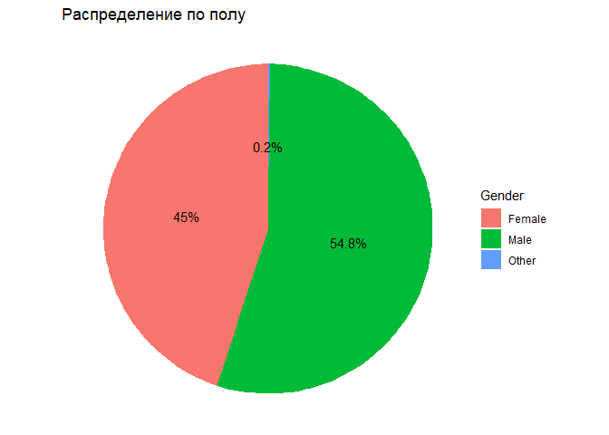

```r
# Создаём таблицу с подсчётом частот
gender_counts <- salary_data %>%
  count(gender)

# Построение круговой диаграммы
ggplot(gender_counts, aes(x = "", y = n, fill = gender)) +
  geom_bar(stat = "identity", width = 1) +
  coord_polar("y", start = 0) +
  theme_void() +
  labs(title = "Распределение по полу", fill = "Gender") +
  geom_text(aes(label = paste0(round(n / sum(n) * 100, 1), "%")),
            position = position_stack(vjust = 0.5))
```

### Наблюдения:

- `Male`: Составляют 54.8% выборки — это наиболее распространённое значение в поле gender.
- `Female`: Представляют 45% данных, что немного меньше по сравнению с Male.
- `Other`: Составляют всего 0.2% выборки. Эта категория, вероятно, связана с некорректным вводом данных или редкими случаями.

Данное распределение показывает, что мужчины и женщины представлены почти равномерно.

## 6.5 Анализ поля education_level

Теперь мы рассмотрим поле `education_level`, чтобы понять его распределение и возможные особенности. Сначала выведем уникальные значения и построим таблицу частот.

```r
unique(salary_data$education_level)
```

```
## [1] "Bachelor's"        "Master's"          "PhD"
## [4] "Bachelor's Degree" "Master's Degree"   "High School"
## [7] "phD"
```

Некоторые значения очень похожи, отобразим их на графике, что увидеть более явно:

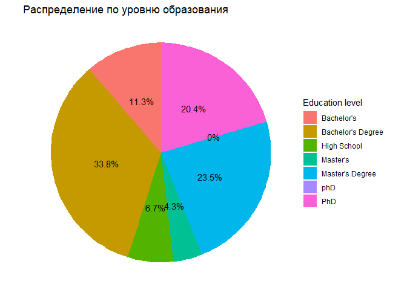

```r
# Создаём таблицу с подсчётом частот
education_counts <- salary_data %>%
  count(education_level)

# Построение круговой диаграммы
ggplot(education_counts, aes(x = "", y = n, fill = education_level)) +
  geom_bar(stat = "identity", width = 1) +
  coord_polar("y", start = 0) +
  theme_void() +
  labs(title = "Распределение по уровню образования", fill = "Education level") +
  geom_text(aes(label = paste0(round(n / sum(n) * 100, 1), "%")),
            position = position_stack(vjust = 0.5))
```

Хорошо, теперь проблема очевидна. Один и тот же уровень образования называется по-разному. Значения должны быть санитизированы.

## 7. Стандартизация колонки education_level

Создадим явный маппинг для всех значений и приведём их к нужному формату:

```r
# Явное сопоставление значений
salary_data <- salary_data %>%
  mutate(education_level = case_when(
    education_level == "Bachelor's Degree" ~ "Bachelor's",
    education_level == "Bachelor's" ~ "Bachelor's",
    education_level == "Master's Degree" ~ "Master's",
    education_level == "Master's" ~ "Master's",
    education_level == "PhD" ~ "PhD",
    education_level == "phD" ~ "PhD",
    education_level == "High School" ~ "High School",
    TRUE ~ education_level # Для любых других значений
  ))

# Проверка результата
table(salary_data$education_level)
```

```
##
##  Bachelor's High School    Master's         PhD
##        3021         448        1860        1369
```

### Комментарии:

- Значения в `education_level` теперь приведены к стандартным категориям:
  - `Bachelor's`
  - `Master's`
  - `PhD`
  - `High School`
- Явное сопоставление устранило дублирующиеся и некорректные значения (например, `phD` → `PhD`).

## 7.1 Распределение уровня образования

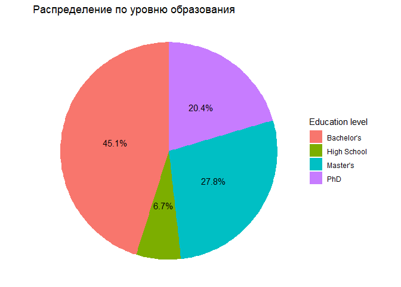

```r
# Создаём таблицу с подсчётом частот
education_counts2 <- salary_data %>%
  count(education_level)

# Построение круговой диаграммы
ggplot(education_counts2, aes(x = "", y = n, fill = education_level)) +
  geom_bar(stat = "identity", width = 1) +
  coord_polar("y", start = 0) +
  theme_void() +
  labs(title = "Распределение по уровню образования", fill = "Education level") +
  geom_text(aes(label = paste0(round(n / sum(n) * 100, 1), "%")),
            position = position_stack(vjust = 0.5))
```

Данные показывают, что большинство людей имеют степень бакалавра или магистра, а уровень образования `PhD` также заметно распространён. Минимальное количество людей с `High School` указывает на то, что более высокие уровни образования являются нормой для рассматриваемых должностей.

## 8. Анализ `job_title`: роли с префиксом `Junior`

Поле `job_title` содержит множество уникальных значений. Для интереса исследуем, сколько позиций имеют префикс `Junior` и составляют ли они значительную долю среди всех должностей.

### 8.1 Проверка случайной выборки должностей

Выведем случайную выборку из `job_title`, чтобы оценить данные:

```r
# Случайная выборка 5 должностей
set.seed(123)  # Для воспроизводимости
sample_n(distinct(salary_data, job_title), 10)
```

```
## # A tibble: 10 × 1
##    job_title
##    <chr>
##  1 Senior IT Consultant
##  2 Front end Developer
##  3 Project Manager
##  4 Junior Operations Coordinator
##  5 Business Intelligence Analyst
##  6 Junior Project Manager
##  7 Administrative Assistant
##  8 Marketing Director
##  9 Juniour HR Coordinator
## 10 Senior Human Resources Specialist
```

### 8.2 Позиции с префиксом `Junior`

Фильтрация должностей с `Junior`

```r
# Фильтрация должностей с "Junior"
junior_job_titles <- salary_data %>%
  filter(str_detect(job_title, regex("Junior", ignore_case = TRUE)))

# Количество должностей с "Junior"
junior_job_title_counts <- junior_job_titles %>%
  count(job_title, sort = TRUE)

# Просмотр результата
junior_job_title_counts
```

```
## # A tibble: 36 × 2
##    job_title                       n
##    <chr>                       <int>
##  1 Junior Sales Associate        142
##  2 Junior HR Generalist           60
##  3 Junior Software Developer      58
##  4 Junior Marketing Manager       51
##  5 Junior Software Engineer       51
##  6 Junior Web Developer           42
##  7 Junior Sales Representative    41
##  8 Junior HR Coordinator          29
##  9 Junior Data Analyst            25
## 10 Junior Business Analyst         8
## # ℹ 26 more rows
```

### 8.3 Общее число позиций с `Junior`

Подсчёт общего числа позиций с `Junior`

```r
# Подсчёт общего числа позиций с "Junior"
total_junior_jobs <- nrow(junior_job_titles)
cat("Total number of job titles containing 'Junior':", total_junior_jobs, "\n")
```

```
## Total number of job titles containing 'Junior': 573
```

### 8.4 Процент позиций с `Junior`

Расчёт процента позиций с `Junior`

```r
# Общее число должностей
total_jobs <- nrow(salary_data)

# Расчёт процента должностей с "Junior"
percent_junior_jobs <- (total_junior_jobs / total_jobs) * 100
cat("Percentage of 'Junior' job titles:", round(percent_junior_jobs, 2), "%\n")
```

```
## Percentage of 'Junior' job titles: 8.55 %
```

### Наблюдения:

Примерно 8% всех позиций в наборе данных относятся к начальному или раннему уровню карьеры.

Это говорит о том, что выборка больше ориентирована на должности среднего и старшего уровня, но включает достаточное количество начальных позиций.

Выборка с Junior подтверждает наличие разнообразных должностей, подходящих для начинающих специалистов.

# 9. Визуализация и исследование

Мы уже создали несколько визуализаций. Теперь рассмотрим распределение зарплат и вычислим центральные тенденции и разброс.

## 9.1 Распределение зарплат

Центральные тенденции и разброс

```r
# Вычисление среднего, медианы и стандартного отклонения для зарплат
salary_mean <- mean(salary_data$salary, na.rm = TRUE)
salary_median <- median(salary_data$salary, na.rm = TRUE)
salary_std <- sd(salary_data$salary, na.rm = TRUE)

# Вывод результатов
cat("Mean Salary:", salary_mean, "\n")
```

```
## Mean Salary: 115329.3
```

```r
cat("Median Salary:", salary_median, "\n")
```

```
## Median Salary: 115000
```

```r
cat("Standard Deviation of Salary:", salary_std, "\n")
```

```
## Standard Deviation of Salary: 52789.79
```

## Наблюдения:

1. Средняя зарплата (Mean Salary): 115,329.25. Это среднее значение зарплат в наборе данных.
2. Медианная зарплата (Median Salary): 115,000. Значение медианы близко к среднему, что указывает на относительно сбалансированное распределение зарплат.
3. Стандартное отклонение (Standard Deviation): 52,789.79. Высокое значение стандартного отклонения показывает широкий диапазон зарплат и значительные различия между ними.

# 9.1.1 Гистограмма распределения зарплат

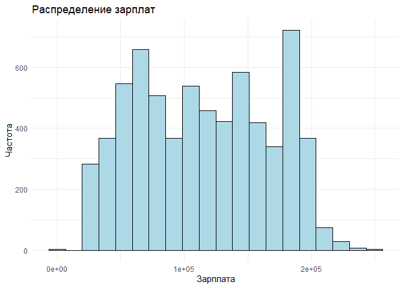

```r
# Построение гистограммы распределения зарплат
ggplot(salary_data, aes(x = salary)) +
  geom_histogram(bins = 20, fill = "lightblue", color = "black") +
  labs(
    title = "Распределение зарплат",
    x = "Зарплата",
    y = "Частота"
  ) +
  theme_minimal()
```

Странные подписи у оси X, попробуем это исправить с пакетом scales():

```r
# Установите пакет scales, если он не установлен
# install.packages("scales")
library(scales)
```

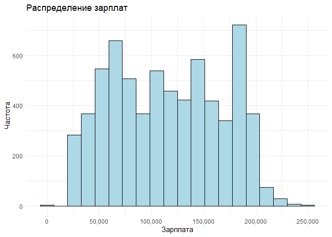

```r
# Построение гистограммы с отформатированной осью X
ggplot(salary_data, aes(x = salary)) +
  geom_histogram(bins = 20, fill = "lightblue", color = "black") +
  scale_x_continuous(
    labels = scales::label_comma(),  # Форматирование в виде чисел с запятыми
    breaks = seq(0, max(salary_data$salary, na.rm = TRUE), by = 50000) # Шаг 50,000
  ) +
  labs(
    title = "Распределение зарплат",
    x = "Зарплата",
    y = "Частота"
  ) +
  theme_minimal()
```

Отлично, так намного нагляднее.

## Наблюдения из визуализации:

1. Зарплаты в основном сконцентрированы в диапазоне от 50,000 до 200,000, с меньшим количеством людей, получающих очень низкие или очень высокие зарплаты.
2. Наличие высоких зарплат (до 250,000) указывает на то, что в наборе данных представлены роли старшего уровня или специализированные позиции, которые получают значительно больше.

## 9.2 Salary vs Years of Experience

Построим диаграмму рассеяния (scatter plot), чтобы визуализировать связь между опытом работы (`years_of_experience`) и зарплатой (`salary`).

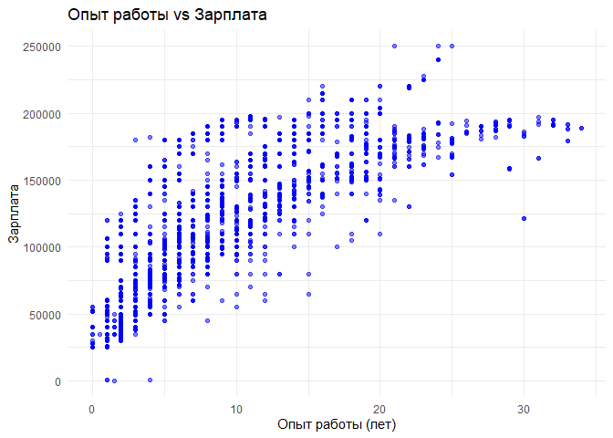

```r
# Построение scatter plot
ggplot(salary_data, aes(x = years_of_experience, y = salary)) +
  geom_point(alpha = 0.5, color = "blue") +
  labs(
    title = "Опыт работы vs Зарплата",
    x = "Опыт работы (лет)",
    y = "Зарплата"
  ) +
  theme_minimal()
```

## Наблюдения:

1. Положительная корреляция: На диаграмме видно, что зарплата, как правило, увеличивается с ростом опыта работы. Это подтверждает гипотезу о том, что опыт играет важную роль в определении зарплаты.
2. Неидеальная линейность:
   - Есть аутлайеры: люди с высокой зарплатой, несмотря на небольшой опыт работы.
   - Также есть люди с низкой зарплатой, несмотря на значительный опыт.
3. Вариация зарплат: На всех уровнях опыта заметен разброс зарплат, что указывает на влияние других факторов, таких как должность, уровень образования или отрасль.

## 9.3 Education и Salary

Построим boxplot, чтобы изучить распределение зарплат для каждой категории уровня образования (`education_level`). Это поможет визуализировать медиану, межквартильный размах и выбросы для каждой группы.

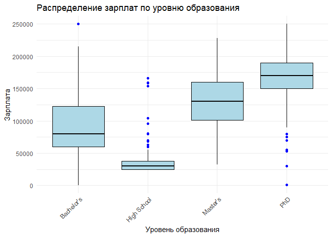

```r
# Построение boxplot
ggplot(salary_data, aes(x = education_level, y = salary)) +
  geom_boxplot(fill = "lightblue", color = "black", outlier.color = "blue", outlier.shape = 16) +
  labs(
    title = "Распределение зарплат по уровню образования",
    x = "Уровень образования",
    y = "Зарплата"
  ) +
  theme_minimal() +
  theme(axis.text.x = element_text(angle = 45, hjust = 1))
```

### Интерпретация:

1. `PhD`: Обладатели степени `PhD` имеют самую высокую медианную зарплату, что подтверждает, что этот уровень образования связан с более высокими доходами.
2. `Master's Degree`: Люди с магистерской степенью также имеют высокие зарплаты, хотя их диапазон несколько шире, чем у `PhD`.
3. `Bachelor's Degree`: Медианная зарплата ниже, чем у обладателей продвинутых степеней, но диапазон показывает, что многие бакалавры зарабатывают на уровне магистров.
4. `High School`: Выпускники средней школы имеют самую низкую медианную зарплату и ограниченный диапазон, что говорит о меньших возможностях для высоких доходов.

### Наблюдения:

1. Зарплата, как правило, увеличивается с ростом уровня образования: обладатели степеней `PhD` и `Master's` получают больше, чем `Bachelor's` или выпускники средней школы.
2. Несмотря на тренд, есть значительное пересечение в распределении зарплат. Некоторые обладатели `Bachelor's` получают столько же, сколько магистры .
3. Широкий диапазон зарплат для всех уровней образования показывает, что помимо образования на зарплату влияют такие факторы, как опыт и должность.

## 9.4 Распределение возраста

В этом разделе мы вычислим центральные тенденции и разброс возраста (`age`) и визуализируем его распределение.

### Центральные тенденции и разброс

```r
# Вычисление среднего, медианы и стандартного отклонения для возраста
age_mean <- mean(salary_data$age, na.rm = TRUE)
age_median <- median(salary_data$age, na.rm = TRUE)
age_std <- sd(salary_data$age, na.rm = TRUE)

# Вывод результатов
cat("Mean Age:", age_mean, "\n")
```

```
## Mean Age: 33.62302
```

```r
cat("Median Age:", age_median, "\n")
```

```
## Median Age: 32
```

```r
cat("Standard Deviation of Age:", age_std, "\n")
```

```
## Standard Deviation of Age: 7.615784
```

### Построение гистограммы распределения возраста

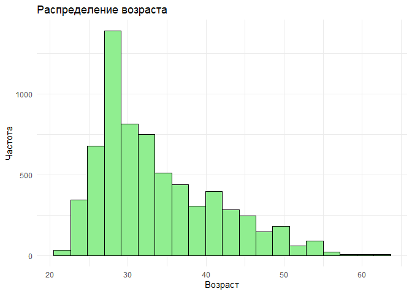

```r
# Построение гистограммы распределения возраста
ggplot(salary_data, aes(x = age)) +
  geom_histogram(bins = 20, fill = "lightgreen", color = "black") +
  labs(
    title = "Распределение возраста",
    x = "Возраст",
    y = "Частота"
  ) +
  theme_minimal()
```

#### Интерпретация:

1. Центральные тенденции:
   - Средний возраст — 33.6 лет.
   - Медианный возраст — 32 года.
   - Поскольку среднее и медиана близки, распределение выглядит относительно симметричным.
2. Разброс: Стандартное отклонение составляет 7.62, что говорит о умеренном разбросе возрастов в выборке.
3. Распределение: Большинство людей находятся в возрасте от 20 до 40 лет, что отражает рабочую популяцию, находящуюся в середине своей карьеры. Меньше людей представлено в возрастных группах старше 50 или младше 25 лет.

# 10. Более глубокое исследование и вопросы для анализа

## 10.1 Распределение мужчин и женщин на разных должностях

### Шаг 1: Топ-5 самых популярных должностей

```r
# Топ-5 самых популярных должностей
top_5_job_titles <- salary_data %>%
  count(job_title, sort = TRUE) %>%
  top_n(5, n)

# Выводим результат
top_5_job_titles
```

```
## # A tibble: 5 × 2
##   job_title                     n
##   <chr>                     <int>
## 1 Software Engineer           518
## 2 Data Scientist              453
## 3 Software Engineer Manager   376
## 4 Data Analyst                363
## 5 Senior Project Engineer     318
```

### Шаг 2: Распределение по полу для топ-5 должностей

```r
# Фильтрация данных для топ-5 должностей и подсчёт распределения по полу
gender_job_distribution <- salary_data %>%
  filter(job_title %in% top_5_job_titles$job_title) %>%
  count(job_title, gender) %>%
  pivot_wider(names_from = gender, values_from = n, values_fill = 0)

# Выводим результат
gender_job_distribution
```

```
## # A tibble: 5 × 4
##   job_title                 Female  Male Other
##   <chr>                      <int> <int> <int>
## 1 Data Analyst                 129   234     0
## 2 Data Scientist               202   251     0
## 3 Senior Project Engineer      103   213     2
## 4 Software Engineer            193   325     0
## 5 Software Engineer Manager    100   276     0
```

### Шаг 3: Визуализация распределения (Stacked Bar Chart)

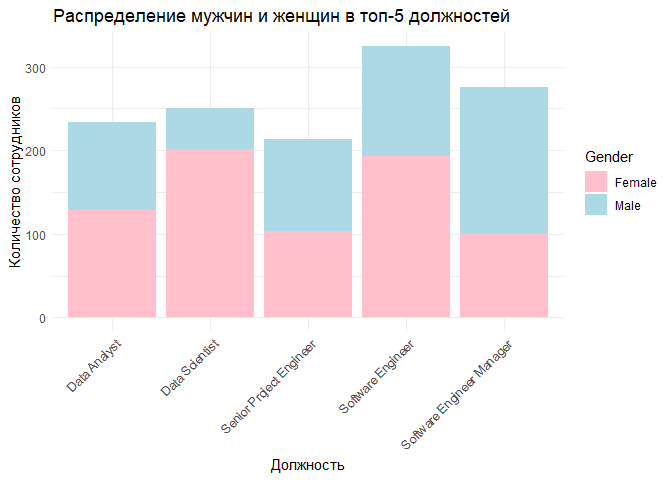

```r
# Построение stacked bar chart для распределения по полу
ggplot(gender_job_distribution, aes(x = job_title)) +
  geom_bar(aes(y = Male, fill = "Male"), stat = "identity", position = "stack") +
  geom_bar(aes(y = Female, fill = "Female"), stat = "identity", position = "stack") +
  scale_fill_manual(values = c("Male" = "lightblue", "Female" = "pink"), name = "Gender") +
  labs(
    title = "Распределение мужчин и женщин в топ-5 должностей",
    x = "Должность",
    y = "Количество сотрудников"
  ) +
  theme_minimal() +
  theme(axis.text.x = element_text(angle = 45, hjust = 1))
```

## 10.2 Влияет ли опыт на зарплату?

Для проверки влияния опыта работы (`years_of_experience`) на зарплату (`salary`), построим диаграмму рассеяния и вычислим корреляцию между этими переменными.

### Построение диаграммы рассеяния

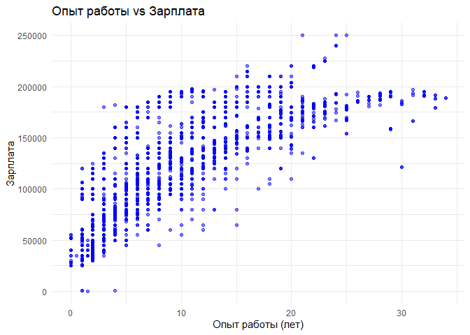

```r
# Построение scatter plot
ggplot(salary_data, aes(x = years_of_experience, y = salary)) +
  geom_point(alpha = 0.5, color = "blue") +
  labs(
    title = "Опыт работы vs Зарплата",
    x = "Опыт работы (лет)",
    y = "Зарплата"
  ) +
  theme_minimal()
```

### Вычисление корреляции

```r
# Вычисление корреляции между опытом работы и зарплатой
experience_salary_corr <- cor(salary_data$years_of_experience, salary_data$salary, use = "complete.obs")

# Вывод результата
cat("Correlation between experience and salary:", experience_salary_corr, "\n")
```

```
## Correlation between experience and salary: 0.8089682
```

## 10.3 Влияют ли результаты экзаменов по математике и программированию на зарплату?

Мы проверим, есть ли связь между результатами экзаменов по математике и программированию (`math_exam_score`, `programming_exam_score`) и зарплатой (`salary`).

### 10.3.1 `Math Exam Score` vs. `Salary`

Построение диаграммы рассеяния

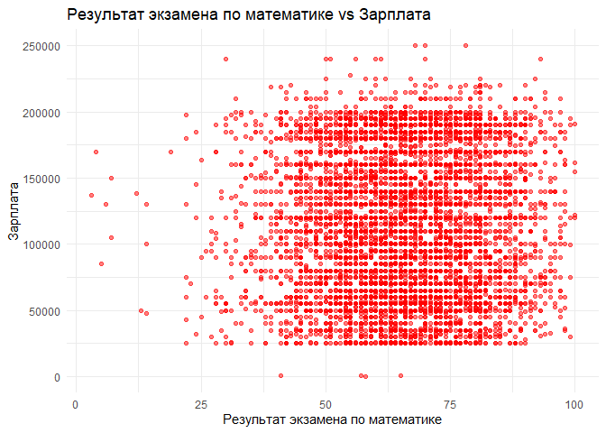

```r
# Диаграмма рассеяния для Math Exam Score vs Salary
ggplot(salary_data, aes(x = math_exam_score, y = salary)) +
  geom_point(alpha = 0.5, color = "red") +
  labs(
    title = "Результат экзамена по математике vs Зарплата",
    x = "Результат экзамена по математике",
    y = "Зарплата"
  ) +
  theme_minimal()
```

Корреляция между математикой и зарплатой

```r
# Вычисление корреляции между Math Exam Score и Salary
math_salary_corr <- cor(salary_data$math_exam_score, salary_data$salary, use = "complete.obs")

# Вывод результата
cat("Correlation between Math exam score and Salary:", math_salary_corr, "\n")
```

```
## Correlation between Math exam score and Salary: 0.02338351
```

#### Наблюдения `Math Exam Score` vs. `Salary`:

Диаграмма рассеяния показывает отсутствие явной тенденции (восходящей или нисходящей), что указывает на слабую связь между результатами экзаменов по математике и зарплатой. Коэффициент корреляции составляет 0.02, что близко к нулю и подтверждает отсутствие значимой зависимости.

### 10.3.2 `Programming Exam Score` vs. `Salary`

Построение диаграммы рассеяния

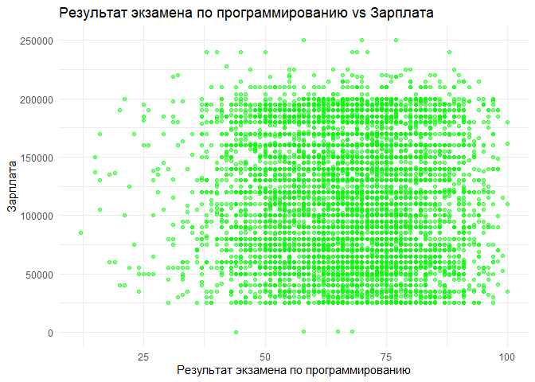

```r
# Диаграмма рассеяния для Programming Exam Score vs Salary
ggplot(salary_data, aes(x = programming_exam_score, y = salary)) +
  geom_point(alpha = 0.5, color = "green") +
  labs(
    title = "Результат экзамена по программированию vs Зарплата",
    x = "Результат экзамена по программированию",
    y = "Зарплата"
  ) +
  theme_minimal()
```

Корреляция между программированием и зарплатой

```r
# Вычисление корреляции между Programming Exam Score и Salary
prog_salary_corr <- cor(salary_data$programming_exam_score, salary_data$salary, use = "complete.obs")

# Вывод результата
cat("Correlation between Programming exam score and Salary:", prog_salary_corr, "\n")
```

```
## Correlation between Programming exam score and Salary: -0.01988079
```

#### Наблюдения `Programming Exam Score` vs. `Salary`:

Аналогично, диаграмма рассеяния для результатов экзамена по программированию также не демонстрирует чёткой связи с зарплатой. Коэффициент корреляции равен -0.02, что подтверждает слабую или отсутствующую зависимость.

### Выводы:

Ни результаты экзаменов по математике, ни по программированию не оказывают значимого влияния на зарплату. На уровень зарплаты, вероятно, больше влияют такие факторы, как опыт работы, образование и должность.

## 10.4 Связь между результатами экзаменов по математике и программированию

Мы проверим, существует ли связь между результатами экзаменов по математике (`math_exam_score`) и программированию (`programming_exam_score`) с помощью диаграммы рассеяния и корреляции.

Построение диаграммы рассеяния

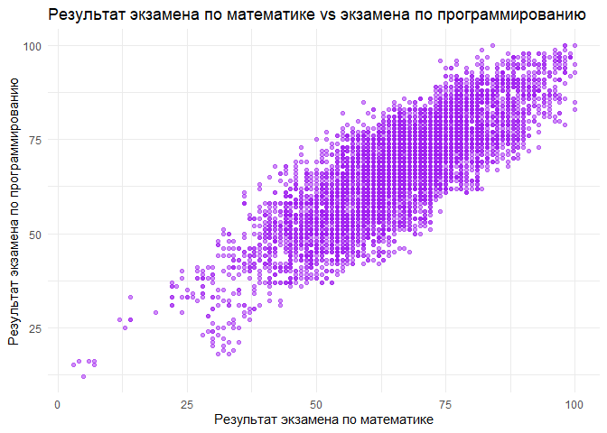

```r
# Диаграмма рассеяния для Math Exam Score vs Programming Exam Score
ggplot(salary_data, aes(x = math_exam_score, y = programming_exam_score)) +
  geom_point(alpha = 0.5, color = "purple") +
  labs(
    title = "Результат экзамена по математике vs экзамена по программированию",
    x = "Результат экзамена по математике",
    y = "Результат экзамена по программированию"
  ) +
  theme_minimal()
```

Вычисление корреляции

```r
# Вычисление корреляции между Math Exam Score и Programming Exam Score
math_prog_corr <- cor(salary_data$math_exam_score, salary_data$programming_exam_score, use = "complete.obs")

# Вывод результата
cat("Correlation between Math and Programming exam scores:", math_prog_corr, "\n")
```

```
## Correlation between Math and Programming exam scores: 0.8208338
```

### Наблюдения:

1. Диаграмма рассеяния: Точки на графике демонстрируют чёткую положительную зависимость между результатами экзаменов по математике и программированию. Большинство точек лежат вдоль диагональной линии, что подтверждает высокую корреляцию между двумя переменными.
2. Корреляция: Коэффициент корреляции, составляет 0.82, что указывает на сильную положительную связь. Это подтверждает, что навыки, необходимые для экзаменов по математике и программированию, тесно связаны.
3. Выводы: Люди с высокими баллами по математике, как правило, показывают аналогично высокие результаты по программированию. Низкие баллы по математике также часто сопровождаются низкими баллами по программированию. Это может свидетельствовать о том, что базовые навыки, такие как аналитическое мышление или логика, одинаково важны для обоих экзаменов.

## 10.5 Влияет ли уровень образования на опыт работы?

Мы исследуем связь между уровнем образования (`education_level`) и средним опытом работы (`years_of_experience`), вычислим средние значения и визуализируем их.

Средний опыт работы по уровням образования

```r
# Группировка по уровню образования и расчёт среднего опыта работы
education_experience <- salary_data %>%
  group_by(education_level) %>%
  summarise(avg_years_experience = mean(years_of_experience, na.rm = TRUE))

# Вывод результатов
education_experience
```

```
## # A tibble: 4 × 2
##   education_level avg_years_experience
##   <chr>                          <dbl>
## 1 Bachelor's                      5.42
## 2 High School                     1.92
## 3 Master's                        9.65
## 4 PhD                            13.9
```

Визуализация: Столбчатая диаграмма

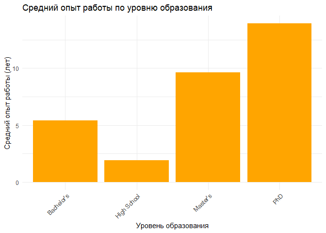

```r
# Построение столбчатой диаграммы
ggplot(education_experience, aes(x = education_level, y = avg_years_experience)) +
  geom_bar(stat = "identity", fill = "orange") +
  labs(
    title = "Средний опыт работы по уровню образования",
    x = "Уровень образования",
    y = "Средний опыт работы (лет)"
  ) +
  theme_minimal() +
  theme(axis.text.x = element_text(angle = 45, hjust = 1))
```

### Наблюдения:

1. Положительная связь между образованием и опытом: Люди с более высоким уровнем образования, такими как `PhD` и `Master's`, имеют больше среднего опыта работы. `PhD` демонстрирует наибольший средний опыт работы, превышающий 13 лет.
2. Бакалавриат (`Bachelor's`): Уровень Bachelor’s имеет средний опыт около 5–6 лет, что меньше, чем у тех, кто завершил магистратуру или докторантуру.
3. Средняя школа (`High School`): Люди с уровнем High School имеют самый низкий средний опыт работы, около 2 лет. Это может быть связано с тем, что эти люди рано выходят на рынок труда и, возможно, имеют меньше возможностей для карьерного роста по сравнению с обладателями высших степеней.

#### Выводы

Более высокие уровни образования требуют больше времени на обучение, что часто означает, что люди старше и имели больше времени для накопления опыта. Дополнительно, продвинутые ступени образования могут открывать доступ к более длительной и стабильной занятости.

## 10.6 Различия в зарплатах в зависимости от уровня образования и должности

Мы исследуем, существуют ли различия в средней зарплате в зависимости от комбинации уровня образования (`education_level`) и должности (`job_title`).

Средняя зарплата по уровням образования и должностям

```r
# Группировка по job_title и education_level и расчёт средней зарплаты
job_education_salary <- salary_data %>%
  group_by(job_title, education_level) %>%
  summarise(avg_salary = mean(salary, na.rm = TRUE)) %>%
  pivot_wider(names_from = education_level, values_from = avg_salary)
# Просмотр результата
job_education_salary
```

```
## # A tibble: 191 × 5
## # Groups:   job_title [191]
##    job_title                     `Bachelor's` `High School` `Master's`    PhD
##    <chr>                                <dbl>         <dbl>      <dbl>  <dbl>
##  1 Account Manager                     75000            NA         NA      NA
##  2 Accountant                          55000            NA         NA      NA
##  3 Administrative Assistant            50000            NA         NA      NA
##  4 Back end Developer                  98744.        74264.    113598.     NA
##  5 Business Analyst                    75000            NA      80000      NA
##  6 Business Development Manager           NA            NA      90000      NA
##  7 Business Intelligence Analyst          NA            NA      85000      NA
##  8 CEO                                250000            NA         NA      NA
##  9 Chief Data Officer                     NA            NA         NA  220000
## 10 Chief Technology Officer               NA            NA         NA  250000
## # ℹ 181 more rows
```

Визуализация: Тепловая карта

```r
# Установка пакета для тепловых карт (если не установлен)
# install.packages("reshape2")

library(reshape2)
```

[figure not shown]

```r
# Преобразование данных для визуализации
job_education_salary_long <- melt(as.data.frame(job_education_salary), id.vars = "job_title", variable.name = "education_level", value.name = "avg_salary")

# Построение тепловой карты
ggplot(job_education_salary_long, aes(x = education_level, y = job_title, fill = avg_salary)) +
  geom_tile(color = "white") +
  scale_fill_gradient(low = "white", high = "blue", na.value = "grey") +
  labs(
    title = "Средняя зарплата по уровню образования и должности",
    x = "Уровень образования",
    y = "Должность",
    fill = "Средняя зарплата"
  ) +
  theme_minimal() +
  theme(axis.text.x = element_text(angle = 45, hjust = 1))
```

Очень сложно воспринимать такой график, попробуем его немного настроить:

```r
# Фильтрация для топ-10 должностей с самой высокой средней зарплатой
top_jobs <- salary_data %>%
  group_by(job_title) %>%
  summarise(avg_salary = mean(salary, na.rm = TRUE)) %>%
  arrange(desc(avg_salary)) %>%
  slice_head(n = 10) %>%
  pull(job_title)

# Отбор данных только для топ-10 должностей
filtered_job_education_salary <- salary_data %>%
  filter(job_title %in% top_jobs) %>%
  group_by(job_title, education_level) %>%
  summarise(avg_salary = mean(salary, na.rm = TRUE)) %>%
  pivot_wider(names_from = education_level, values_from = avg_salary)
```

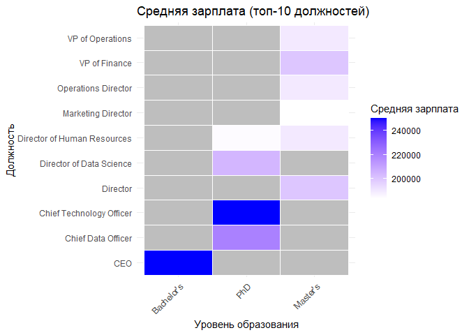

```r
# Преобразование данных в формат для тепловой карты
filtered_job_education_salary_long <- melt(as.data.frame(filtered_job_education_salary), id.vars = "job_title", variable.name = "education_level", value.name = "avg_salary")

# Построение обновлённой тепловой карты
ggplot(filtered_job_education_salary_long, aes(x = education_level, y = job_title, fill = avg_salary)) +
  geom_tile(color = "white") +
  scale_fill_gradient(low = "white", high = "blue", na.value = "grey") +
  labs(
    title = "Средняя зарплата (топ-10 должностей)",
    x = "Уровень образования",
    y = "Должность",
    fill = "Средняя зарплата"
  ) +
  theme_minimal() +
  theme(axis.text.x = element_text(angle = 45, hjust = 1))
```

### Наблюдения:

1. **Связь между уровнем образования и зарплатой**:
   - У `CEO`, неожиданно, самая высокая средняя зарплата связана с уровнем образования `Bachelor's`, а не с `PhD` или `Master's`. Это может быть вызвано специфическими характеристиками выборки или уникальными карьерными траекториями.
   - Для таких должностей, как `Chief Technology Officer` и `Chief Data Officer`, степень `PhD` явно связана с более высокими зарплатами.
2. **Исключения**:
   - Должности, такие как `VP of Operations` и `VP of Finance`, демонстрируют слабую зависимость зарплаты от уровня образования. Возможно, на этих ролях большее значение имеют навыки управления и опыт.
3. **Выделяющиеся роли**:
   - У `Chief Technology Officer` и `Chief Data Officer` степень `PhD` даёт значительное преимущество в зарплате.
   - Напротив, для ролей `Director` и `Marketing Director` влияние образования на зарплату минимально.
4. **Выводы**:
   - Хотя в большинстве случаев высшее образование приводит к более высоким зарплатам, есть исключения, такие как `CEO`, где фактор образования играет меньшую роль, и, возможно, большее влияние оказывают лидерские качества и опыт.

# 11. Сводные таблицы

## 11.1 Гендер vs Уровень образования – Анализ зарплат

Мы создадим сводную таблицу для анализа зависимости средней зарплаты от пола (`gender`) и уровня образования (`education_level`), а также визуализируем данные с помощью тепловой карты.

Сводная таблица: Средняя зарплата по полу и уровню образования

```r
# Создание сводной таблицы
gender_education_pivot <- salary_data %>%
  group_by(gender, education_level) %>%
  summarise(avg_salary = mean(salary, na.rm = TRUE)) %>%
  pivot_wider(names_from = education_level, values_from = avg_salary)
# Просмотр результата
gender_education_pivot
```

```
## # A tibble: 3 × 5
## # Groups:   gender [3]
##   gender `Bachelor's` `High School` `Master's`     PhD
##   <chr>         <dbl>         <dbl>      <dbl>   <dbl>
## 1 Female       89165.        30756.    122695. 160266.
## 2 Male         98972.        39381.    140061. 168711.
## 3 Other           NA        119949.    161393      NA
```

Визуализация: Тепловая карта

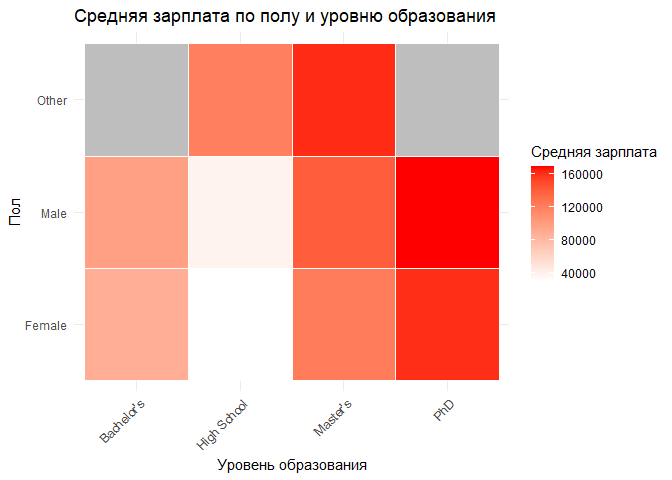

```r
# Преобразование данных в формат для тепловой карты
gender_education_long <- melt(as.data.frame(gender_education_pivot), id.vars = "gender", variable.name = "education_level", value.name = "avg_salary")

# Построение тепловой карты
ggplot(gender_education_long, aes(x = education_level, y = gender, fill = avg_salary)) +
  geom_tile(color = "white") +
  scale_fill_gradient(low = "white", high = "red", na.value = "grey") +
  labs(
    title = "Средняя зарплата по полу и уровню образования",
    x = "Уровень образования",
    y = "Пол",
    fill = "Средняя зарплата"
  ) +
  theme_minimal() +
  theme(axis.text.x = element_text(angle = 45, hjust = 1))
```

# 11.2 Сводная таблица для опыта и зарплаты по уровню образования

Мы создадим сводную таблицу, чтобы проанализировать средние значения опыта работы (`years_of_experience`) и зарплаты (`salary`) по уровням образования (`education_level`).

Сводная таблица: Опыт и зарплата по уровням образования

```r
# Группировка по уровню образования и расчёт среднего опыта и зарплаты
experience_salary_pivot <- salary_data %>%
  group_by(education_level) %>%
  summarise(
    avg_years_experience = mean(years_of_experience, na.rm = TRUE),
    avg_salary = mean(salary, na.rm = TRUE)
  )

# Просмотр результата
experience_salary_pivot
```

```
## # A tibble: 4 × 3
##   education_level avg_years_experience avg_salary
##   <chr>                          <dbl>      <dbl>
## 1 Bachelor's                      5.42     95083.
## 2 High School                     1.92     36707.
## 3 Master's                        9.65    130112.
## 4 PhD                            13.9     165651.
```

## Наблюдения:

1. Связь между уровнем образования и опытом работы: Обладатели степени `PhD` имеют самый высокий средний опыт работы (13.9 лет), что значительно больше, чем у других уровней образования. `Master's` также демонстрирует высокий средний опыт (9.65 лет), что почти в два раза больше, чем у тех, кто окончил только Bachelor’s (5.42 года). Выпускники `High School` имеют самый низкий средний опыт работы (1.92 года), что может быть связано с более ранним выходом на рынок труда.
2. Связь между уровнем образования и зарплатой: Зарплата стабильно возрастает с ростом уровня образования: Выпускники `High School` имеют самую низкую среднюю зарплату (36,707). `Bachelor's` повышает среднюю зарплату почти в 3 раза по сравнению с `High School` (95,083). `Master's` и `PhD` показывают самые высокие зарплаты — 130,112 и 165,651, соответственно.
3. Выводы: Более высокий уровень образования связан как с большим количеством лет профессионального опыта, так и с более высоким уровнем дохода. Это подтверждает, что инвестиции в высшее образование приводят к долгосрочным преимуществам для карьеры и дохода. Здесь хорошое место для рекламной интеграции HSE.

# 11.3 Зарплаты после 10 лет опыта

Мы сравним зарплаты `Data Scientist` с уровнями образования `Bachelor's` и `PhD`, которые имеют как минимум 10 лет опыта работы. Также проверим различия между мужчинами и женщинами в этих категориях.

Фильтрация данных

```r
# Фильтрация данных: только Data Scientists с уровнями образования Bachelor's и PhD, имеющие как минимум 10 лет опыта
filtered_data <- salary_data %>%
  filter(
    job_title == "Data Scientist",
    education_level %in% c("Bachelor's", "PhD"),
    years_of_experience >= 10
  )

# Группировка по уровню образования и полу, расчёт средней зарплаты
salary_comparison <- filtered_data %>%
  group_by(education_level, gender) %>%
  summarise(avg_salary = mean(salary, na.rm = TRUE)) %>%
  pivot_wider(names_from = gender, values_from = avg_salary)
# Просмотр результата
salary_comparison
```

```
## # A tibble: 2 × 3
## # Groups:   education_level [2]
##   education_level    Male Female
##   <chr>             <dbl>  <dbl>
## 1 Bachelor's      150000      NA
## 2 PhD             174607. 186000
```

Визуализация: Сравнение зарплат

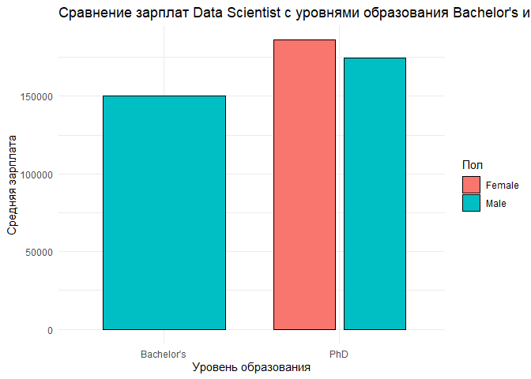

```r
# Построение столбчатой диаграммы для сравнения зарплат
ggplot(filtered_data, aes(x = education_level, y = salary, fill = gender)) +
  stat_summary(fun = mean, geom = "bar", position = position_dodge(width = 0.8), width = 0.7, color = "black") +
  labs(
    title = "Сравнение зарплат Data Scientist с уровнями образования Bachelor's и PhD (10+ лет опыта)",
    x = "Уровень образования",
    y = "Средняя зарплата",
    fill = "Пол"
  ) +
  theme_minimal() +
  theme(axis.text.x = element_text(angle = 0, hjust = 0.5))
```

## Наблюдения:

1. Сравнение зарплат между уровнями образования: Обладатели степени `PhD` стабильно зарабатывают больше, чем те, кто имеет степень `Bachelor's`. Это подчёркивает значимость высшего уровня образования для высокооплачиваемых позиций, таких как Data Scientist.
2. Гендерные различия для PhD: Среди обладателей степени `PhD`, женщины показывают чуть более высокую среднюю зарплату по сравнению с мужчинами. Это может быть связано с наличием меньшего количества данных, что приводит к преобладанию высоких зарплат в выборке женщин.
3. Отсутствие женщин в категории `Bachelor's`: В данных отсутствуют женщины с уровнем образования `Bachelor's` и более чем 10-летним опытом работы. Это ограничивает возможности анализа для этой категории.
4. Выводы: Уровень `PhD` обеспечивает значительное увеличение средней зарплаты, независимо от пола. Гендерные различия в категории `PhD` минимальны, что может говорить о более равномерной оплате труда на этом уровне образования.

# Основные выводы

1. Гендерный разрыв: Мужчины чаще зарабатывают больше женщин на одинаковых позициях и уровнях образования, но в некоторых категориях, как `PhD`, разница минимальна или отсутствует.
2. Образование: Высшее образование (особенно `PhD` и `Master's`) = выше зарплата. Но для некоторых ролей (`Software Engineer`) степень `Bachelor's` всё ещё конкурентоспособна.
3. Опыт работы: Больше опыта = больше денег, но не всегда. Например, есть роли, где высокий доход доступен даже с меньшим опытом.
4. Экзамены: Результаты по математике и программированию почти не влияют на зарплату. Рынок ценит реальные навыки и опыт, а не академические баллы.

# Итоги: